# Exercise: Income inequality by education. (Worked Example)

```r
library(tidyverse)
byCollege <- read_csv("https://info3370.github.io/sp23/assets/data/byCollege.csv")
```

A few observations about the data

- There are 4 variables and 360 observations.
- The `year` and `income` variables are numeric
- The `education` and `quantity` variables are characters

Below I create the `ggplot`. Students might have different labels, which is fine.

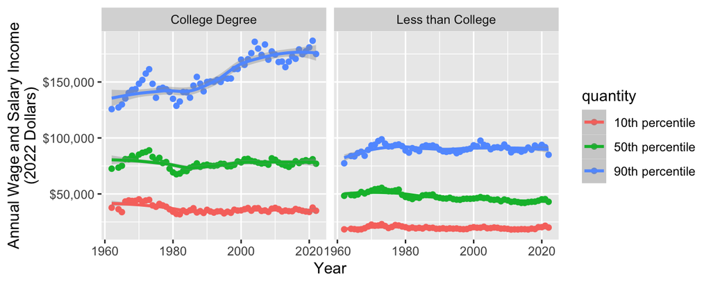

```r
ggplot(data = byCollege,
       mapping = aes(x = year, y = income,
                     color = quantity)) +
  geom_point() +
  geom_smooth() +
  facet_wrap(~education) +
  scale_y_continuous(name = "Annual Wage and Salary Income\n(2022 Dollars)",
                     labels = scales::label_dollar()) +
  scale_x_continuous(name = "Year")
```

## Interpretation

Over the period from 1962 to 2022, the visualization shows one major change: the 90th percentile of real wage and salary incomes among college graduates rose substantially, from about $125,000 in 1962 to about $175,000 in 2022.

Meanwhile, the 50th and 10th percentiles among college graduate showed almost no change. Likewise, the 10th, 50th, and 90th percentiles are all fairly flat among those without a college degree. If anything, the median annual wage among those with less than a college degree declined slightly.

This evidence suggests a broader story: inequality in wage and salary incomes has risen primarily because of rising pay at the top of the earnings distribution among college-educated workers.